# Binary effects of sediment on the growth of adult corals

Lillian J. Tuttle

9/24/2020

#### Here I will explore how DEPOSITED AND SUSPENDED sediment affects the GROWTH of tropical, scleractinean coral ADULTS. The database to be used is comprised of data extracted from studies deemed relevant during the systematic literature review process.

# The Dataset

## Deposited Sediment

Specifically, we will explore the results of 55 datapoints from 10 studies conducted in 2 oceans on 10 species within 7 genera.

```
##    n
## 1 55
```

```
##     Ref  n
## 1  DS18 14
## 2  DS43 12
## 3  DS26  6
## 4  DS68  6
## 5  DS11  4
## 6  DS21  4
## 7  DS28  3
## 8  DS36  2
## 9  DS42  2
## 10 DS69  2
```

```
##                        Ref_name  n
## 1       Piniak and Brown (2008) 14
## 2     Peters and Pilson (1985)  12
## 3          Flores et al. (2012)  6
## 4  Sofonia (2006) PhD Chapter 3  6
## 5          Lirman et al. (2008)  4
## 6                Rogers (1979)   4
## 7    Sofonia and Anthony (2008)  3
## 8             Gil et al. (2016)  2
## 9           Gowan et al. (2014)  2
## 10           Zill et al. (2017)  2
```

```
##      Ocean  n
## 1  Pacific 35
## 2 Atlantic 20
```

```
##                       Gsp  n
## 1  Pocillopora_damicornis 14
## 2      Astrangia_poculata 12
## 3      Acropora_millepora  6
## 4  Turbinaria_mesenterina  6
## 5    Acropora_cervicornis  4
## 6    Porites_lobata/lutea  4
## 7      Montipora_digitata  3
## 8      Porites_astreoides  2
## 9             Porites_rus  2
## 10    Siderastrea_siderea  2
```

```
##   Updated_Genus  n
## 1   Pocillopora 14
## 2     Astrangia 12
## 3      Acropora 10
## 4       Porites  8
## 5    Turbinaria  6
## 6     Montipora  3
## 7   Siderastrea  2
```

## Suspended Sediment

```
##    n
## 1 79
```

```
##     Ref  n
## 1 SS22c 28
## 2  SS01 12
## 3 SS03a 12
## 4 SS22a 10
## 5 SS22b  8
## 6  SS08  6
## 7  SS25  3
```

```
##                     Ref_name  n
## 1                  Rice 1984 46
## 2               Anthony 1999 12
## 3 Anthony and Fabricius 2000 12
## 4         Flores et al. 2012  6
## 5          Te 2001 Chapter 6  3
```

```
##      Ocean  n
## 1 Atlantic 46
## 2  Pacific 33
```

```
##                         Gsp  n
## 1     Goniastrea_retiformis 12
## 2        Porites_cylindrica 12
## 3       Cladocora_arbuscula  8
## 4         Manicina_areolata  8
## 5        Solenastrea_hyades  8
## 6        Acropora_millepora  6
## 7       Siderastrea_radians  6
## 8        Isophyllia_sinuosa  4
## 9      Phyllangia_americana  4
## 10          Scolymia_lacera  4
## 11 Stephanocoenia_michelini  4
```

```
##     Updated_Genus  n
## 1      Goniastrea 12
## 2         Porites 12
## 3       Cladocora  8
## 4        Manicina  8
## 5     Solenastrea  8
## 6        Acropora  6
## 7     Siderastrea  6
## 8      Isophyllia  4
## 9      Phyllangia  4
## 10       Scolymia  4
## 11 Stephanocoenia  4
```

# Exploratory plots

First let’s explore all data from all species for which there is binary data about the presence of a reduction in ‘growth rate’ as a result of exposure to deposited/suspended sediment.

##### DEFINITIONS:

- ‘**Growth rate**’ is defined as coral growth measured in any way, e.g., tissue/skeletal linear extension or increase in weight.

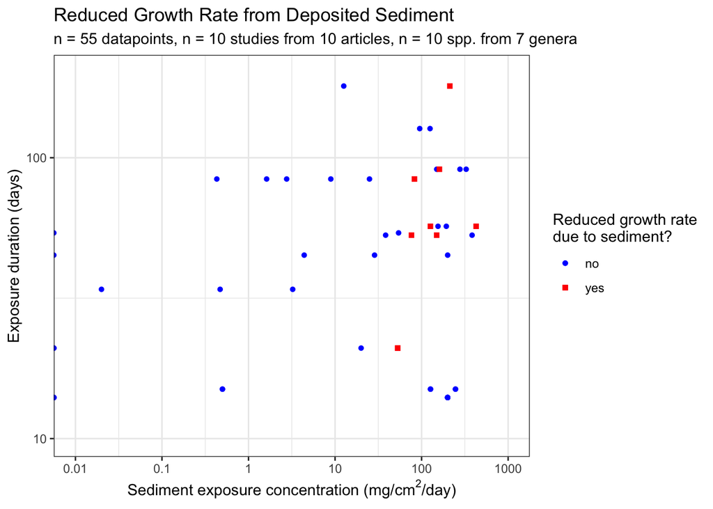

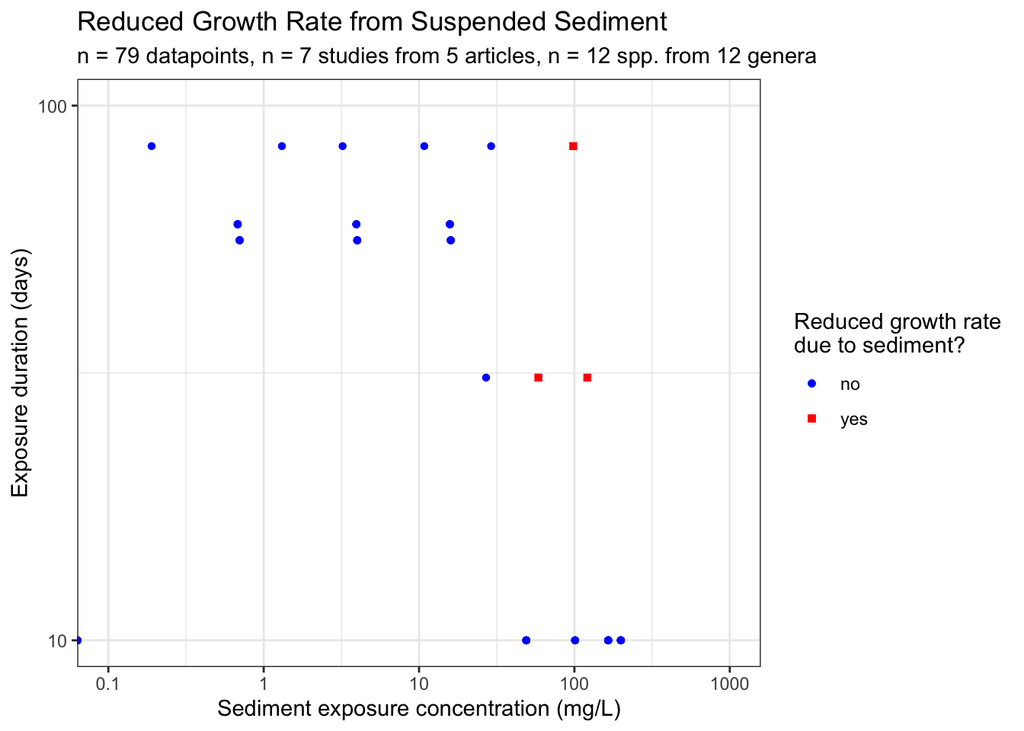

# Threshold Analyses with Binary Data

Now let’s calculate the thresholds, based on the binary data explored above.

##### DEFINITIONS:

- ‘**LOAEL**’, or the ‘lowest observed adverse effect level’ is defined as the lowest dose at which there was an observed adverse effect.
- ‘**NOAEL**’, or the ‘no observed adverse effect level’ is defined as the highest dose at which there was NOT an observed adverse effect.
- ‘**Adverse effect**’ is defined here as any response of a coral individual, colony, or experimental treatment group that *may* negatively affect the coral’s fitness and/or survival. These adverse effects may include sublethal physiological changes (e.g., significantly reduced growth or photosynthetic rates when compared to coral in ambient/control conditions), bleaching/tissue loss, and mortality. This definition of adverse effect is independent of its magnitude, so while the affect may have potentially reduced fitness, its magnitude may be sufficiently small that the fitness effect is not measureable.

## DEPOSITED SEDIMENT

#### NOAEL/LOAEL defined by exposure concentration

```
##   LOAEL
## 1    53
```

```
##   NOAEL
## 1  38.4
```

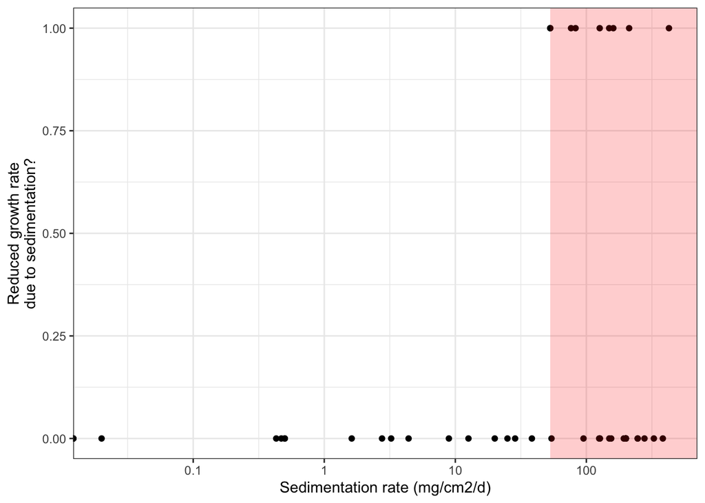

### NOAEL/LOAEL defined by exposure duration

```
##   LOAEL
## 1    21
```

```
##   NOAEL
## 1    21
```

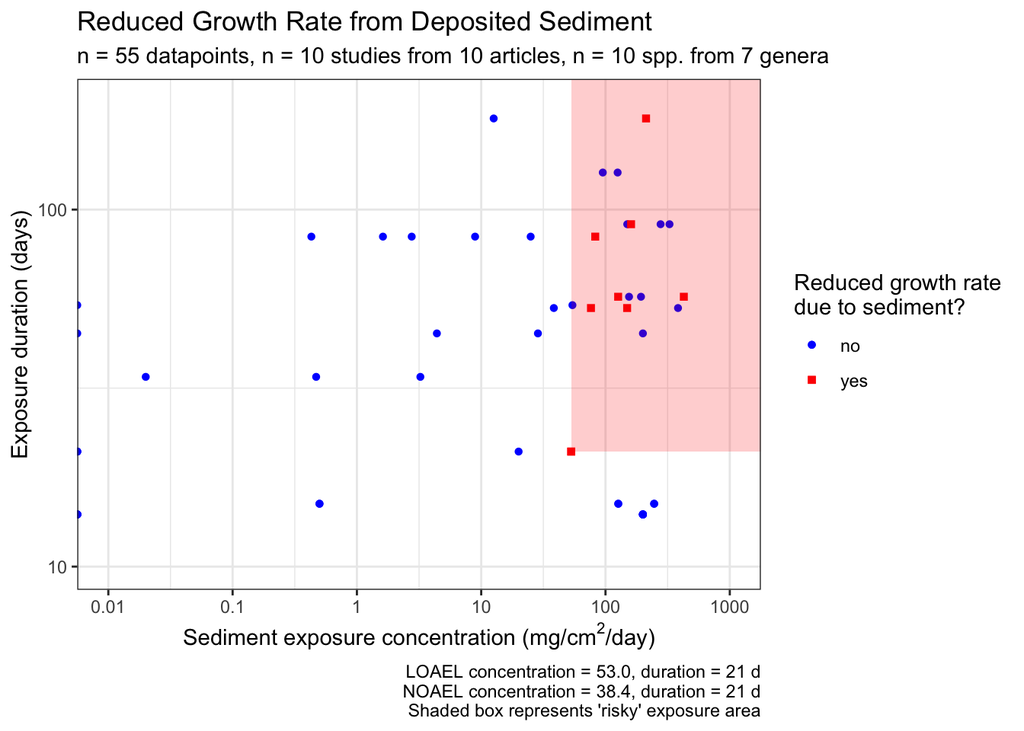

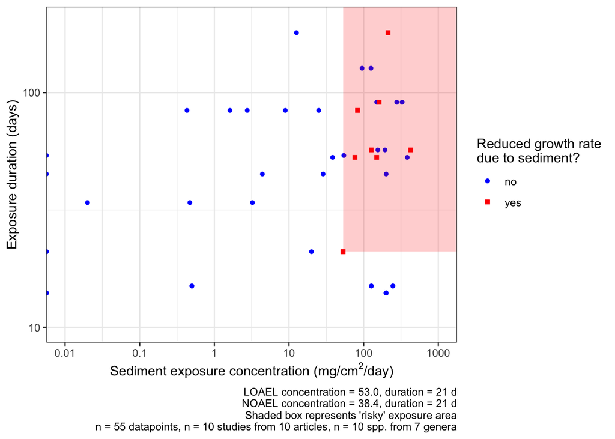

## SUSPENDED SEDIMENT

#### NOAEL/LOAEL defined by exposure concentration

```
##   LOAEL
## 1  58.6
```

```
##   NOAEL
## 1    49
```

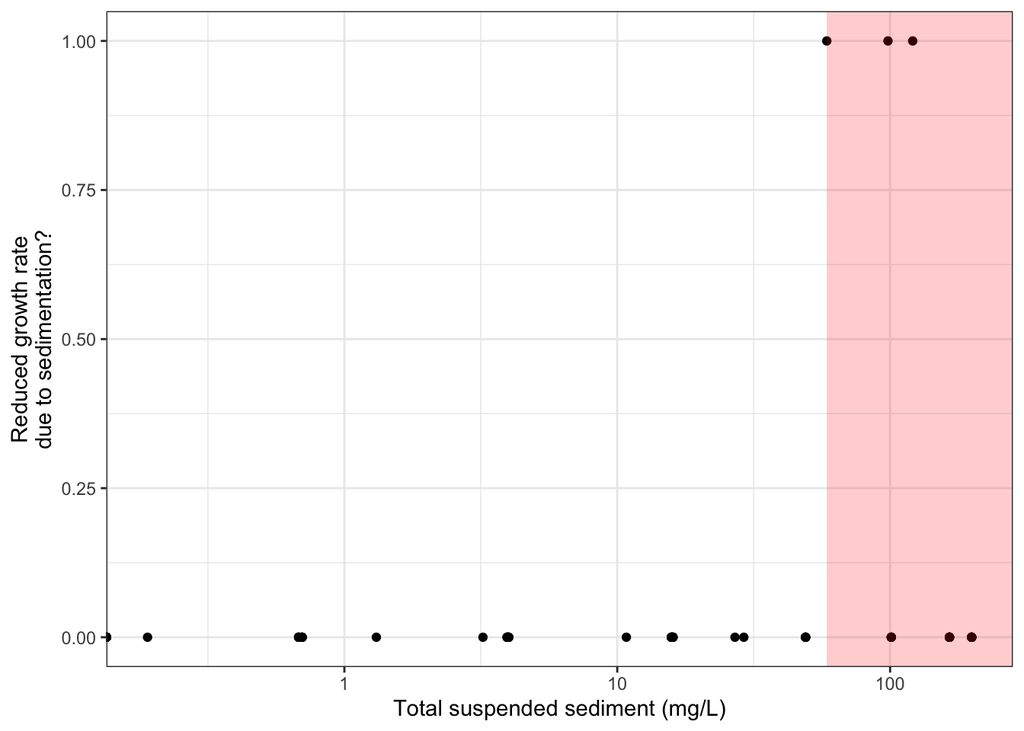

### NOAEL/LOAEL defined by exposure duration

```
##   LOAEL
## 1    31
```

```
##   NOAEL
## 1    31
```

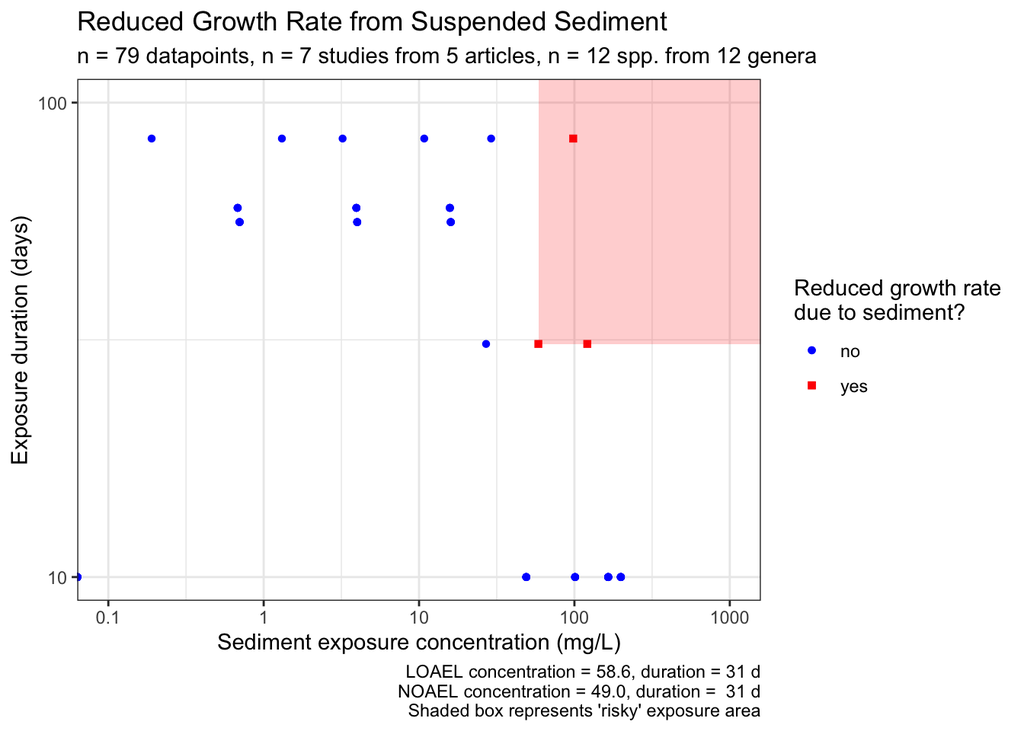

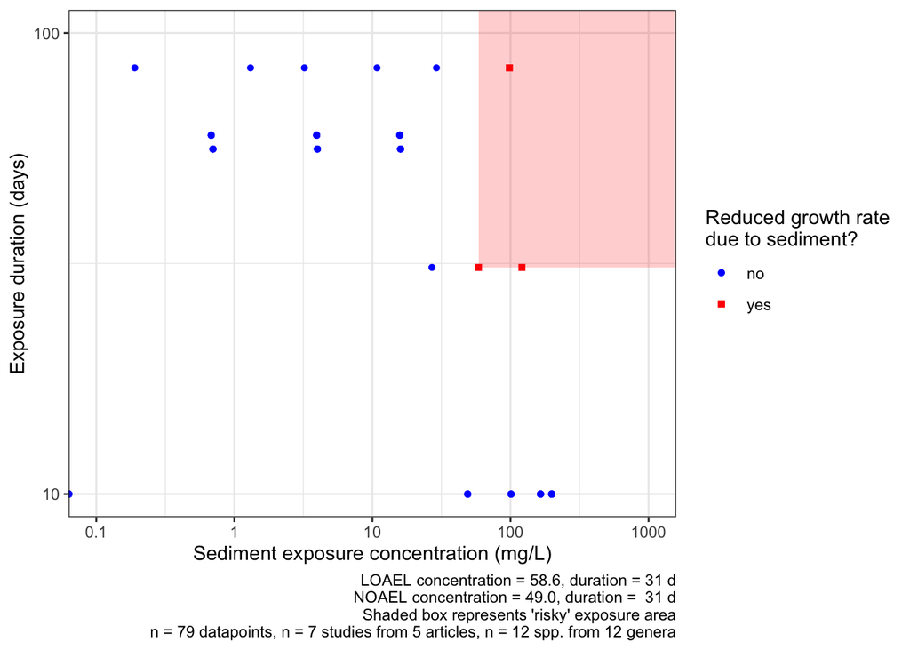

# Logistic Regression Model Fitting

## Deposited Sediment

[output not shown]

```
## Data: growthDS2
## Models:
## mod6: Binary_reduced_growth ~ Sed_level_stand_mg * Sed_exposure_days +
## mod6:     (1 | Gsp)
## mod9: Binary_reduced_growth ~ Sed_level_stand_mg * Sed_exposure_days +
## mod9:     (1 | Ref)
## mod12: Binary_reduced_growth ~ Sed_level_stand_mg * Sed_exposure_days +
## mod12:     (1 | Gsp) + (1 | Ref)
## mod15: Binary_reduced_growth ~ Sed_level_stand_mg * Sed_exposure_days +
## mod15:     (1 | Ref_name/Ref)
## mod18: Binary_reduced_growth ~ Sed_level_stand_mg * Sed_exposure_days +
## mod18:     (1 | Gsp) + (1 | Ref_name)
## mod21: Binary_reduced_growth ~ Sed_level_stand_mg * Sed_exposure_days +
## mod21:     (1 | Gsp) + (1 | Ref_name/Ref)
##       npar    AIC    BIC  logLik deviance Chisq Df Pr(>Chisq)
## mod6     5 48.671 57.115 -19.335   38.671
## mod9     5 48.671 57.115 -19.335   38.671     0  0     <2e-16 ***
## mod12    6 50.671 60.804 -19.335   38.671     0  1          1
## mod15    6 50.671 60.804 -19.335   38.671     0  0          1
## mod18    6 50.671 60.804 -19.335   38.671     0  0          1
## mod21    7 52.671 64.493 -19.335   38.671     0  1          1
## ---
## Signif. codes:  0 '***' 0.001 '**' 0.01 '*' 0.05 '.' 0.1 ' ' 1
```

```
## Data: growthDS2
## Models:
## mod7: Binary_reduced_growth ~ Sed_level_stand_mg + (1 | Ref)
## mod8: Binary_reduced_growth ~ Sed_level_stand_mg + Sed_exposure_days +
## mod8:     (1 | Ref)
## mod9: Binary_reduced_growth ~ Sed_level_stand_mg * Sed_exposure_days +
## mod9:     (1 | Ref)
##      npar    AIC    BIC  logLik deviance  Chisq Df Pr(>Chisq)
## mod7    3 46.979 52.046 -20.490   40.979
## mod8    4 48.821 55.577 -20.410   40.821 0.1581  1     0.6909
## mod9    5 48.671 57.115 -19.335   38.671 2.1501  1     0.1426
```

```
## Data: growthDS2
## Models:
## mod4: Binary_reduced_growth ~ Sed_level_stand_mg + (1 | Gsp)
## mod7: Binary_reduced_growth ~ Sed_level_stand_mg + (1 | Ref)
## mod10: Binary_reduced_growth ~ Sed_level_stand_mg + (1 | Gsp) + (1 |
## mod10:     Ref)
## mod13: Binary_reduced_growth ~ Sed_level_stand_mg + (1 | Ref_name/Ref)
## mod16: Binary_reduced_growth ~ Sed_level_stand_mg + (1 | Gsp) + (1 |
## mod16:     Ref_name)
##       npar    AIC    BIC  logLik deviance  Chisq Df Pr(>Chisq)
## mod4     3 48.109 53.176 -21.055   42.109
## mod7     3 46.979 52.046 -20.490   40.979 1.1303  0     <2e-16 ***
## mod10    4 48.979 55.735 -20.490   40.979 0.0000  1          1
## mod13    4 48.979 55.735 -20.490   40.979 0.0000  0     <2e-16 ***
## mod16    4 48.979 55.735 -20.490   40.979 0.0000  0          1
## ---
## Signif. codes:  0 '***' 0.001 '**' 0.01 '*' 0.05 '.' 0.1 ' ' 1
```

```
## Generalized linear mixed model fit by maximum likelihood (Laplace
##   Approximation) [glmerMod]
##  Family: binomial  ( logit )
## Formula: Binary_reduced_growth ~ Sed_level_stand_mg + (1 | Ref)
##    Data: growthDS2
##
##      AIC      BIC   logLik deviance df.resid
##     47.0     52.0    -20.5     41.0       37
##
## Scaled residuals:
##     Min      1Q  Median      3Q     Max
## -0.8237 -0.4501 -0.2375 -0.2192  2.1042
##
## Random effects:
##  Groups Name        Variance Std.Dev.
##  Ref    (Intercept) 4.124    2.031
## Number of obs: 40, groups:  Ref, 10
##
## Fixed effects:
##                     Estimate Std. Error z value Pr(>|z|)
## (Intercept)        -2.213952   1.470025  -1.506    0.132
## Sed_level_stand_mg  0.001559   0.004494   0.347    0.729
```

### Effect estimates

```
## [1] 0.85
```

```
##
## p    0  1
##   0 31  6
##   1  0  3
```

```
## Area under the curve: 0.8817
```

```
##                     R2m       R2c
## theoretical 0.003894842 0.5579725
## delta       0.002955256 0.4233682
```

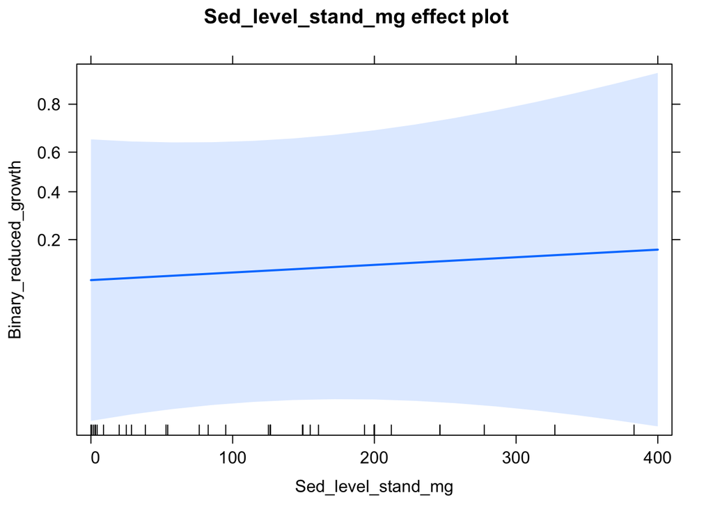

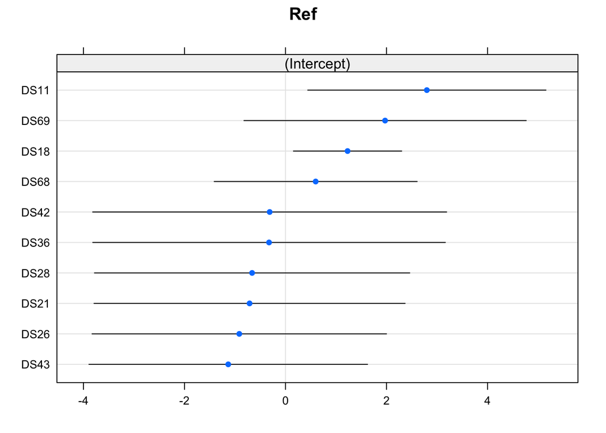

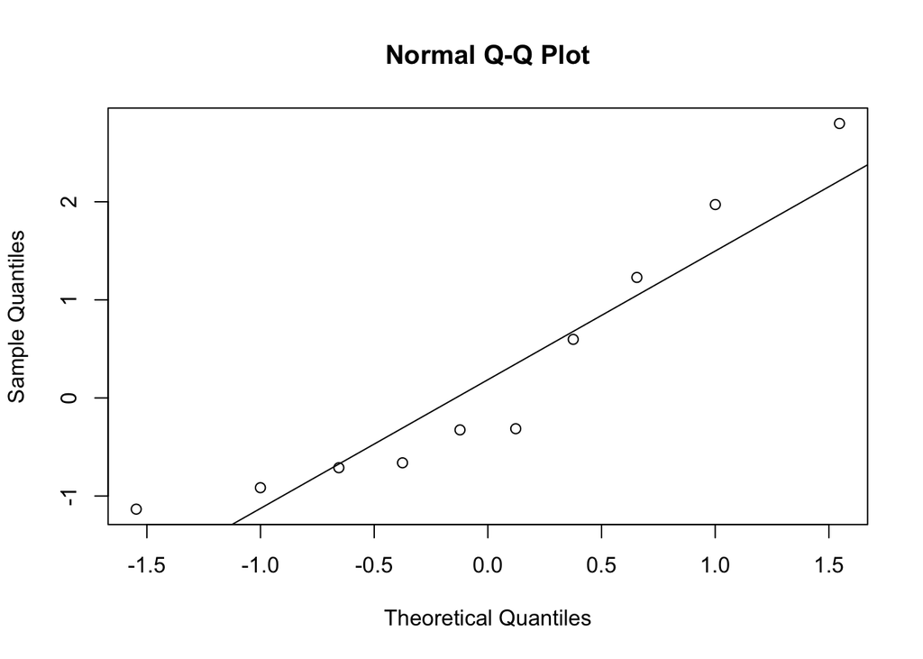

```
##  Groups Name        Std.Dev.
##  Ref    (Intercept) 2.0307
```

```
## [1] 7.619567
```

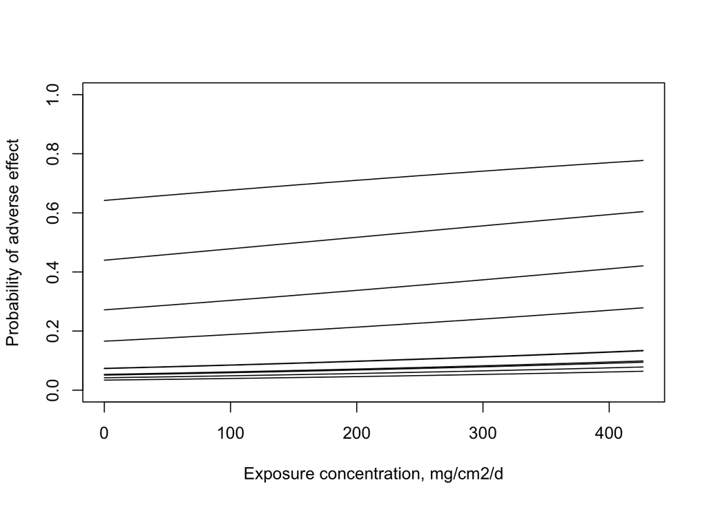

There is no evidence to suggest that the exposure concentration of deposited sediment affects the odds of a reduction in coral growth rate (GLMM p=0.729).

### Prediction figure

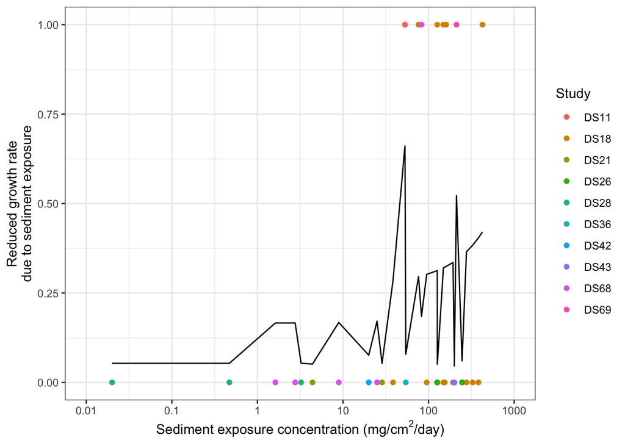

```r
#Overlaying glmm results on figure, but prediction line is jagged...
pred_mod7 <- predict(mod7, newdata=growthDS2, type="response")
growthDS3 <- cbind(growthDS2, pred_mod7)

growthDS_plot <- ggplot(data = growthDS3) +
    geom_point(mapping = aes(
      x = Sed_level_stand_mg,
      y = Binary_reduced_growth,
      color = Ref)) +
    labs(x = expression("Sediment exposure concentration (mg/cm"^"2"*"/day)"),
         y = "Reduced growth rate\ndue to sediment exposure",
         color = "Study") +
    scale_x_log10(limits=c(0.01,1000),breaks=c(0.01,0.1,1,10,100,1000),
                  label=c("0.01","0.1","1","10","100","1000")) +
    geom_line(aes(x = Sed_level_stand_mg, y = pred_mod7), inherit.aes=FALSE) +
    theme_bw()

growthDS_plot
```

That plot is confusing to interpret. Let’s see if I can plot the average marginal probability, i.e., the average change in probability of the outcome across the range of the predictor of interest. This is described in some detail at the following, useful website: https://stats.idre.ucla.edu/r/dae/mixed-effects-logistic-regression/

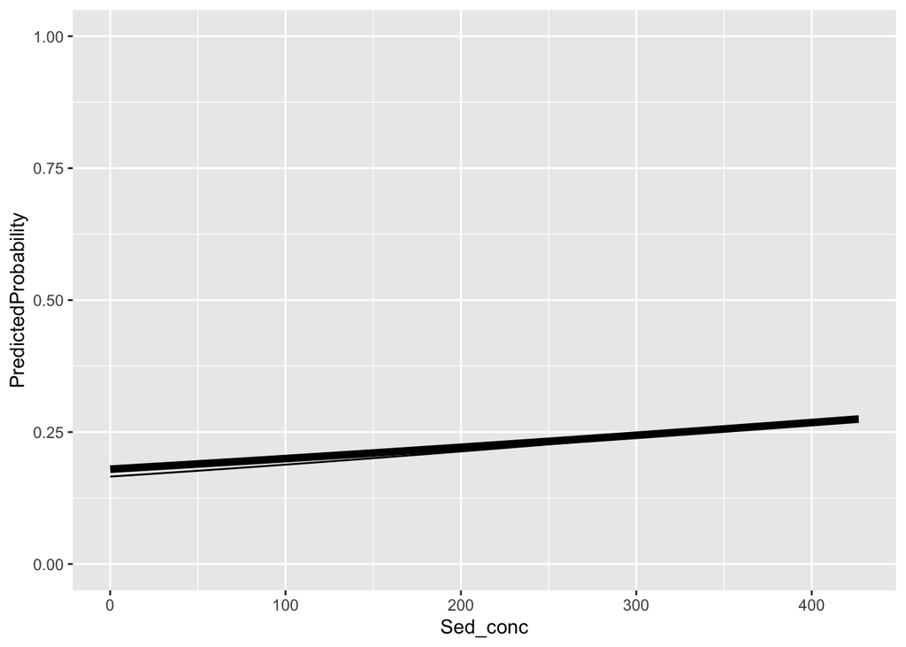

```r
#summary(growthDS2$Sed_level_stand_mg)
#   Min. 1st Qu.  Median    Mean 3rd Qu.    Max.
#   0.02   35.95  126.70  134.49  200.00  426.80

jvalues <- with(growthDS2, seq(from = min(Sed_level_stand_mg), to = max(Sed_level_stand_mg), length.out = 100))

# calculate predicted probabilities and store in a list
pp <- lapply(jvalues, function(j) {
    growthDS2$Sed_level_stand_mg <- j
    predict(mod7, newdata = growthDS2, type = "response")
})

# average marginal predicted probability across a few different sediment levels
#sapply(pp[c(1, 20, 40, 60, 80, 100)], mean)
## [1] 0.1797186 0.1960244 0.2142042 0.2333993 0.2535694 0.2746604
# get the means with lower and upper quartiles
plotdat <- t(sapply(pp, function(x) {
    c(M = mean(x), med = median(x), quantile(x, c(0.25, 0.75)))
}))

# add in Sed_level_stand_mg values and convert to data frame
plotdat <- as.data.frame(cbind(plotdat, jvalues))

# better names and show the first few rows
colnames(plotdat) <- c("PredictedProbability", "MedianProbability",
                       "LowerQuantile", "UpperQuantile", "Sed_conc")
#head(plotdat)

# plot average marginal predicted probabilities
ggplot(plotdat, aes(x = Sed_conc)) +
  geom_line(aes(y = PredictedProbability), size = 2) +
  geom_line(aes(y = MedianProbability), size = 0.5) +
  ylim(c(0, 1))
```

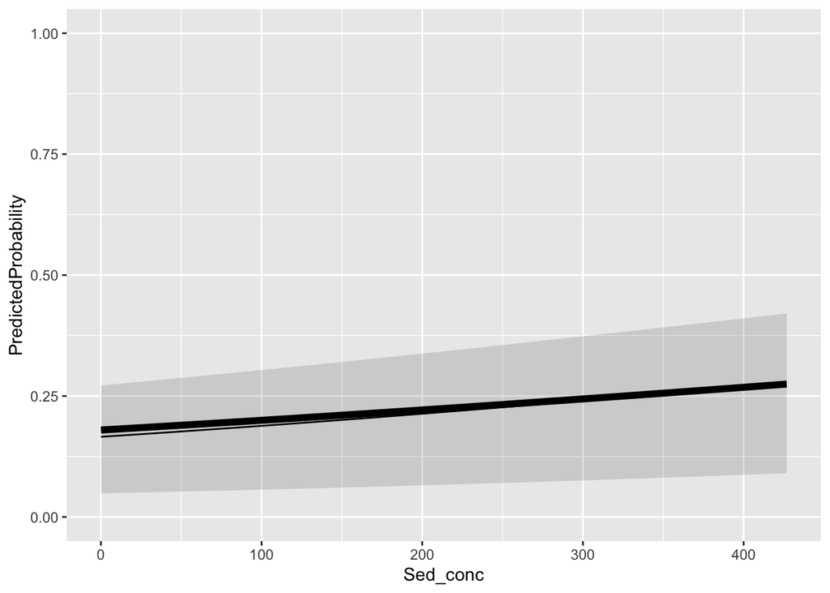

```r
ggplot(plotdat, aes(x = Sed_conc)) +
  geom_ribbon(aes(ymin = LowerQuantile, ymax = UpperQuantile), alpha = 0.15) +
  geom_line(aes(y = PredictedProbability), size = 2) +
  geom_line(aes(y = MedianProbability), size = 0.5) +
  ylim(c(0, 1))
```

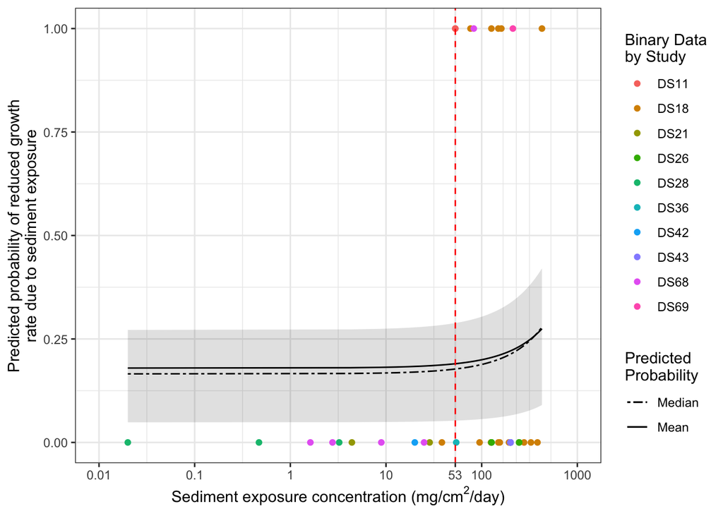

```r
#Overlaying average marginal predicted probabilities on figure
#by Ref
growthDS_plot3 <- ggplot() +
    geom_point(data = growthDS2, mapping = aes(
      x = Sed_level_stand_mg,
      y = Binary_reduced_growth,
      color = Ref)) +
    labs(x = expression("Sediment exposure concentration (mg/cm"^"2"*"/day)"),
         y = "Predicted probability of reduced growth\nrate due to sediment exposure",
         color = "Binary Data\nby Study",
         linetype = "Predicted\nProbability") +
    scale_x_log10(limits=c(0.01,1000), breaks=c(0.01,0.1,1,10,100,1000,loael),
                  label=c("0.01","0.1","1","10","100","1000",round(loael,digits=1))) +
    geom_ribbon(data = plotdat, aes(x = Sed_conc, y = PredictedProbability,
                                    ymin = LowerQuantile, ymax = UpperQuantile),
                alpha = 0.15) +
    geom_line(data = plotdat, aes(x = Sed_conc, y = PredictedProbability,
                                  linetype = "twodash")) +
    geom_line(data = plotdat, aes(x = Sed_conc, y = MedianProbability,
                                  linetype = "solid")) +
    geom_vline(xintercept=loael, linetype="dashed", color = "red") +
    theme_bw() +
    scale_linetype_manual(values=c("twodash", "solid"), labels = c("Median","Mean"))

growthDS_plot3
```

## Suspended Sediment

```
## boundary (singular) fit: see ?isSingular
## boundary (singular) fit: see ?isSingular
## boundary (singular) fit: see ?isSingular
## boundary (singular) fit: see ?isSingular
## boundary (singular) fit: see ?isSingular
## boundary (singular) fit: see ?isSingular
```

```
## Data: growthSS2
## Models:
## modSS5: Binary_reduced_growth ~ Sed_level_stand_mg + Sed_exposure_days +
## modSS5:     (1 | Gsp)
## modSS8: Binary_reduced_growth ~ Sed_level_stand_mg + Sed_exposure_days +
## modSS8:     (1 | Ref)
## modSS11: Binary_reduced_growth ~ Sed_level_stand_mg + Sed_exposure_days +
## modSS11:     (1 | Gsp) + (1 | Ref)
## modSS14: Binary_reduced_growth ~ Sed_level_stand_mg + Sed_exposure_days +
## modSS14:     (1 | Ref_name/Ref)
## modSS17: Binary_reduced_growth ~ Sed_level_stand_mg + Sed_exposure_days +
## modSS17:     (1 | Gsp) + (1 | Ref_name)
## modSS20: Binary_reduced_growth ~ Sed_level_stand_mg + Sed_exposure_days +
## modSS20:     (1 | Gsp) + (1 | Ref_name/Ref)
##         npar    AIC    BIC  logLik deviance Chisq Df Pr(>Chisq)
## modSS5     4 12.463 19.864 -2.2318   4.4635
## modSS8     4 12.463 19.864 -2.2318   4.4635 0e+00  0     1.0000
## modSS11    5 14.463 23.714 -2.2318   4.4635 0e+00  1     0.9976
## modSS14    5 14.463 23.714 -2.2317   4.4634 2e-04  0     <2e-16 ***
## modSS17    5 14.463 23.714 -2.2317   4.4634 0e+00  0     <2e-16 ***
## modSS20    6 16.463 27.564 -2.2317   4.4634 0e+00  1     1.0000
## ---
## Signif. codes:  0 '***' 0.001 '**' 0.01 '*' 0.05 '.' 0.1 ' ' 1
```

```
## Data: growthSS2
## Models:
## modSS4: Binary_reduced_growth ~ Sed_level_stand_mg + (1 | Gsp)
## modSS7: Binary_reduced_growth ~ Sed_level_stand_mg + (1 | Ref)
## modSS10: Binary_reduced_growth ~ Sed_level_stand_mg + (1 | Gsp) + (1 |
## modSS10:     Ref)
## modSS13: Binary_reduced_growth ~ Sed_level_stand_mg + (1 | Ref_name/Ref)
## modSS16: Binary_reduced_growth ~ Sed_level_stand_mg + (1 | Gsp) + (1 |
## modSS16:     Ref_name)
## modSS19: Binary_reduced_growth ~ Sed_level_stand_mg + (1 | Gsp) + (1 |
## modSS19:     Ref_name/Ref)
##         npar    AIC    BIC  logLik deviance  Chisq Df Pr(>Chisq)
## modSS4     3 15.222 20.773 -4.6111   9.2222
## modSS7     3 16.831 22.381 -5.4154  10.8308 0.0000  0          1
## modSS10    4 18.831 26.232 -5.4155  10.8309 0.0000  1          1
## modSS13    4 13.353 20.754 -2.6767   5.3533 5.4776  0     <2e-16 ***
## modSS16    4 13.353 20.754 -2.6767   5.3533 0.0000  0     <2e-16 ***
## modSS19    5 15.353 24.604 -2.6767   5.3533 0.0000  1          1
## ---
## Signif. codes:  0 '***' 0.001 '**' 0.01 '*' 0.05 '.' 0.1 ' ' 1
```

```
## Data: growthSS2
## Models:
## modSS7: Binary_reduced_growth ~ Sed_level_stand_mg + (1 | Ref)
## modSS8: Binary_reduced_growth ~ Sed_level_stand_mg + Sed_exposure_days +
## modSS8:     (1 | Ref)
##        npar    AIC    BIC  logLik deviance  Chisq Df Pr(>Chisq)
## modSS7    3 16.831 22.381 -5.4154  10.8308
## modSS8    4 12.463 19.864 -2.2318   4.4635 6.3672  1    0.01162 *
## ---
## Signif. codes:  0 '***' 0.001 '**' 0.01 '*' 0.05 '.' 0.1 ' ' 1
```

```
## Generalized linear mixed model fit by maximum likelihood (Laplace
##   Approximation) [glmerMod]
##  Family: binomial  ( logit )
## Formula: Binary_reduced_growth ~ Sed_level_stand_mg + Sed_exposure_days +
##     (1 | Ref)
##    Data: growthSS2
##
##      AIC      BIC   logLik deviance df.resid
##     12.5     19.9     -2.2      4.5       43
##
## Scaled residuals:
##       Min        1Q    Median        3Q       Max
## -0.006672  0.000000  0.000000  0.000000  0.042438
##
## Random effects:
##  Groups Name        Variance Std.Dev.
##  Ref    (Intercept) 40328    200.8
## Number of obs: 47, groups:  Ref, 7
##
## Fixed effects:
##                     Estimate Std. Error z value Pr(>|z|)
## (Intercept)        -131.9266    32.6945  -4.035 5.46e-05 ***
## Sed_level_stand_mg    0.5171     0.1485   3.483 0.000496 ***
## Sed_exposure_days     1.2014     0.4328   2.776 0.005506 **
## ---
## Signif. codes:  0 '***' 0.001 '**' 0.01 '*' 0.05 '.' 0.1 ' ' 1
```

### Effect estimates

```
## [1] 1
```

```
##
## p    0  1
##   0 44  0
##   1  0  3
```

```
## Area under the curve: 1
```

```
##                    R2m       R2c
## theoretical 0.01607677 0.9999197
## delta       0.01607623 0.9998865
```

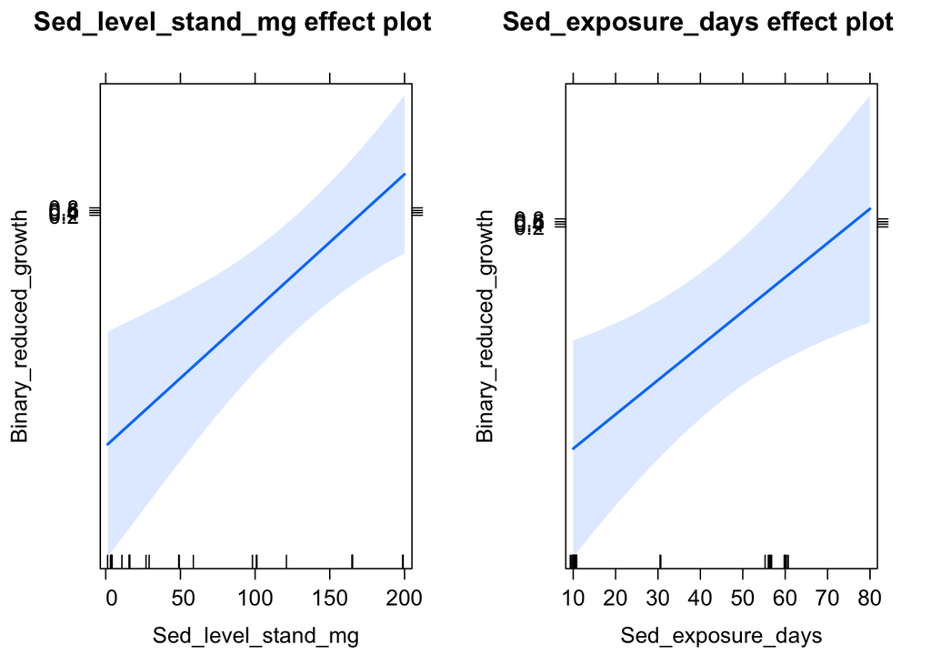

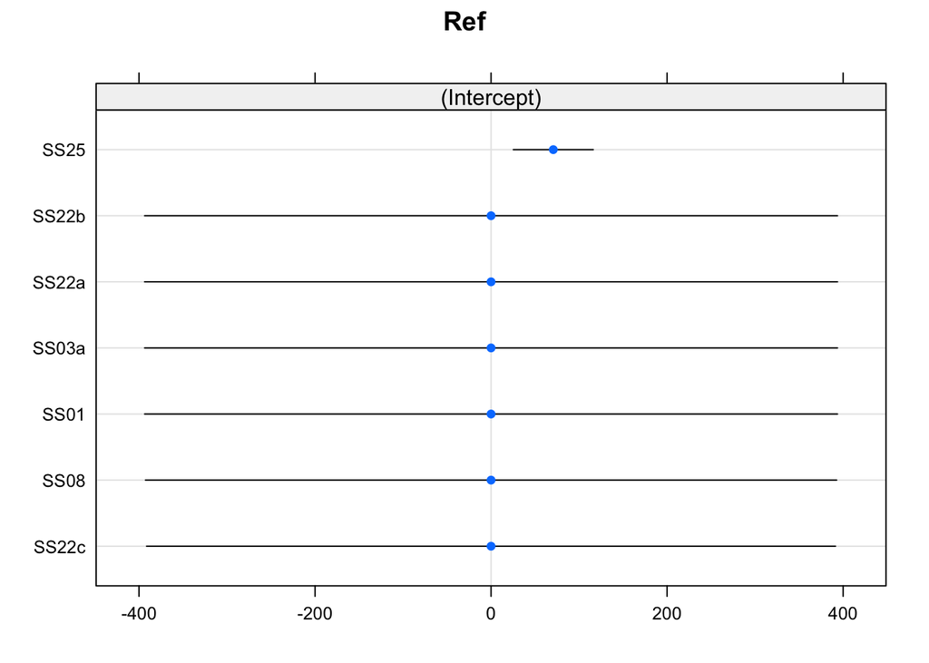

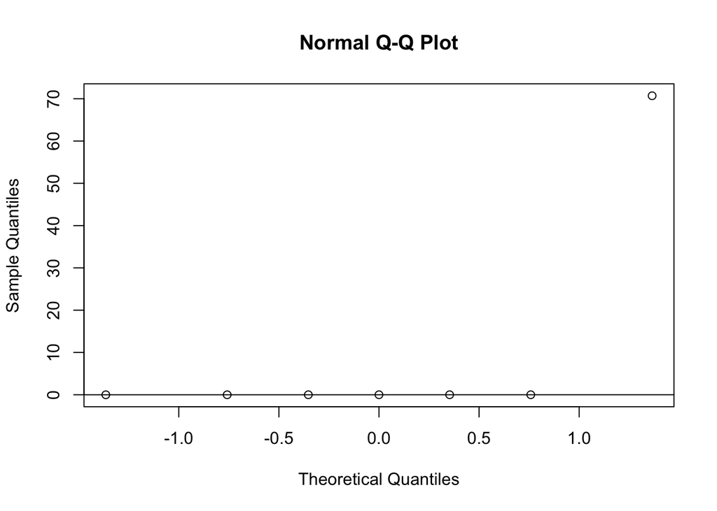

```
##  Groups Name        Std.Dev.
##  Ref    (Intercept) 200.82
```

```
## [1] 1.638791e+87
```

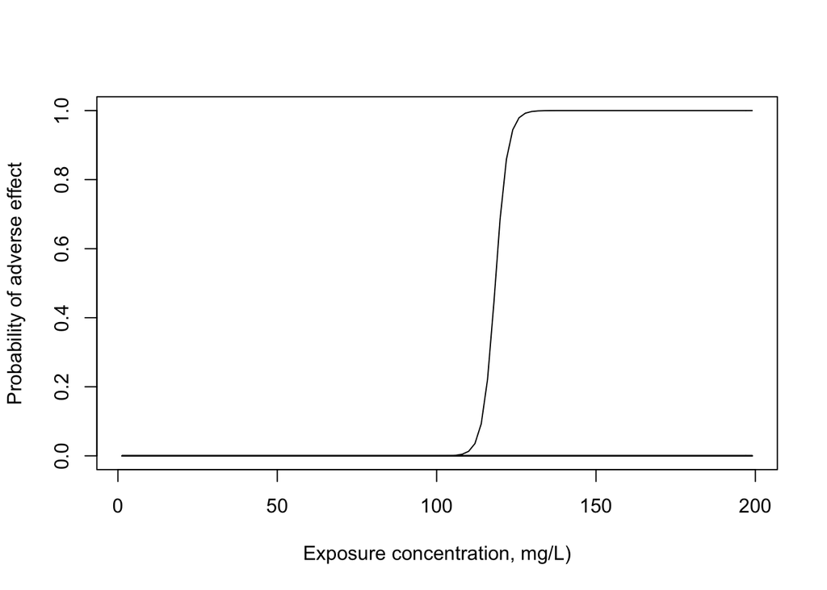

```
##                             Est           LL           UL
## (Intercept)        1.932565e-40 9.902971e-60 3.771402e-21
## Sed_level_stand_mg 1.431039e+00 1.169650e+00 1.750842e+00
## Sed_exposure_days  2.299567e+00 1.277298e+00 4.139996e+00
```

For every doubling in exposure concentration of suspended sediment, the odds of a reduction in coral growth rate increase by 1.4 times (95% CI 1.2,1.8, GLMM z = 3.483, p = 0.0005), while holding exposure duration constant (and accounting for the random effect of study). For every doubling in exposure duration of suspended sediment, the odds of a reduction in coral growth rate increase by 2.3 times (95% CI 1.3,4.1; GLMM z = 2.776, p = 0.006), while holding exposure concentration constant (and accounting for the random effect of study).

### Prediction figures

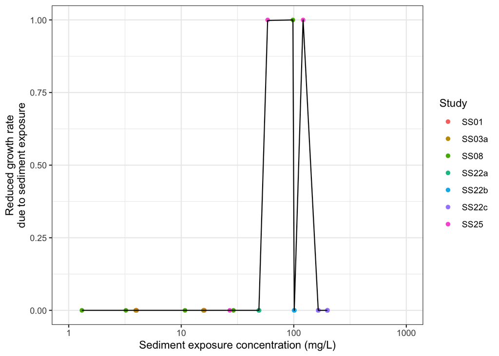

```r
#Overlaying glmm results on figure, but prediction line is jagged...
pred_modSS8 <- predict(modSS8, newdata=growthSS2, type="response")
growthSS3 <- cbind(growthSS2, pred_modSS8)

growthSS_plot <- ggplot(data = growthSS3) +
    geom_point(mapping = aes(
      x = Sed_level_stand_mg,
      y = Binary_reduced_growth,
      color = Ref)) +
    labs(x = "Sediment exposure concentration (mg/L)",
         y = "Reduced growth rate\ndue to sediment exposure",
         color = "Study") +
    scale_x_log10(limits=c(1,1000),breaks=c(0.01,0.1,1,10,100,1000),
                  label=c("0.01","0.1","1","10","100","1000")) +
    geom_line(aes(x = Sed_level_stand_mg, y = pred_modSS8), inherit.aes=FALSE) +
    theme_bw()

growthSS_plot
```

That plot is confusing to interpret. Let’s see if I can plot the average marginal probability, i.e., the average change in probability of the outcome across the range of the predictor of interest. This is described in some detail at the following, useful website: https://stats.idre.ucla.edu/r/dae/mixed-effects-logistic-regression/

#### By sediment exposure concentration

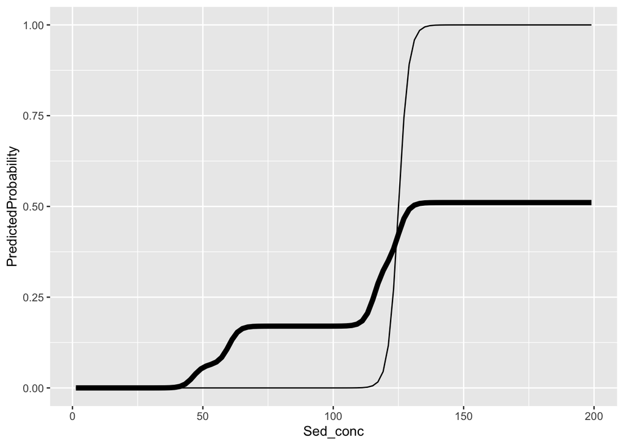

```r
#summary(growthSS2$Sed_level_stand_mg)
#   Min. 1st Qu.  Median    Mean 3rd Qu.    Max.
#   1.31   15.79   49.00   78.83  165.00  199.00

jvalues <- with(growthSS2, seq(from = min(Sed_level_stand_mg), to = max(Sed_level_stand_mg), length.out = 100))

# calculate predicted probabilities and store in a list
pp <- lapply(jvalues, function(j) {
    growthSS2$Sed_level_stand_mg <- j
    predict(modSS8, newdata = growthSS2, type = "response")
})

# average marginal predicted probability across a few different sediment levels
#sapply(pp[c(1, 20, 40, 60, 80, 100)], mean)
## [1] 0.1797186 0.1960244 0.2142042 0.2333993 0.2535694 0.2746604
# get the means with lower and upper quartiles
plotdat <- t(sapply(pp, function(x) {
    c(M = mean(x), med = median(x), quantile(x, c(0.25, 0.75)))
}))

# add in Sed_level_stand_mg values and convert to data frame
plotdat <- as.data.frame(cbind(plotdat, jvalues))

# better names and show the first few rows
colnames(plotdat) <- c("PredictedProbability", "MedianProbability",
                       "LowerQuantile", "UpperQuantile", "Sed_conc")
#head(plotdat)

# plot average marginal predicted probabilities
ggplot(plotdat, aes(x = Sed_conc)) +
  geom_line(aes(y = PredictedProbability), size = 2) +
  geom_line(aes(y = MedianProbability), size = 0.5) +
  ylim(c(0, 1))
```

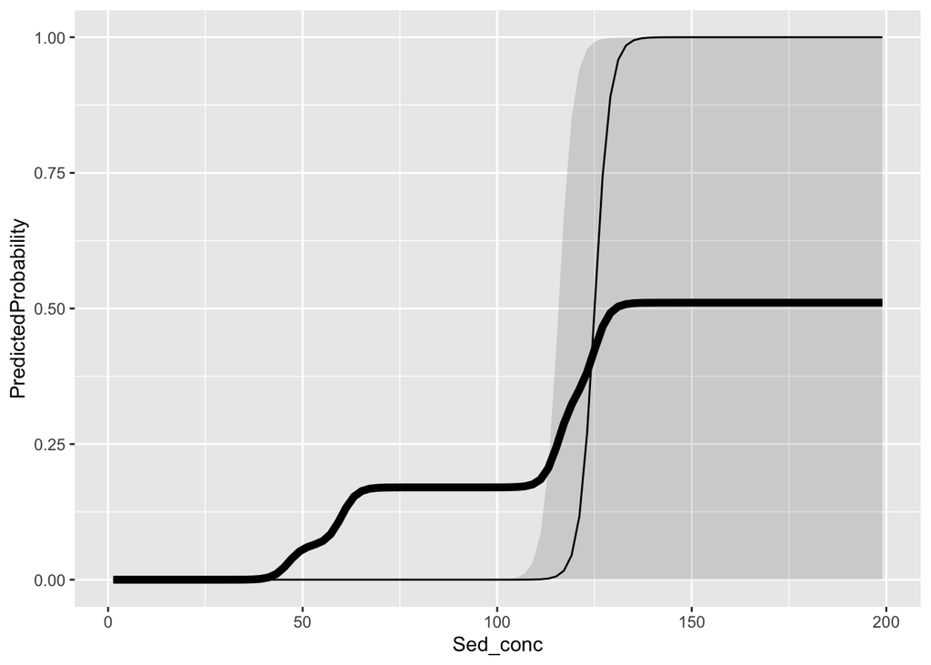

```r
ggplot(plotdat, aes(x = Sed_conc)) +
  geom_ribbon(aes(ymin = LowerQuantile, ymax = UpperQuantile), alpha = 0.15) +
  geom_line(aes(y = PredictedProbability), size = 2) +
  geom_line(aes(y = MedianProbability), size = 0.5) +
  ylim(c(0, 1))
```

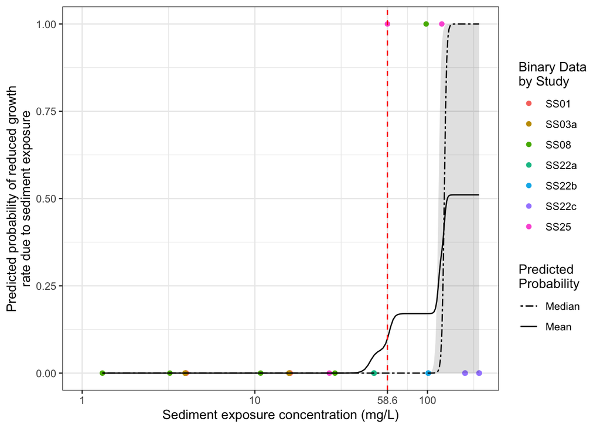

```r
#Overlaying average marginal predicted probabilities on figure
#by Ref
growthSS_plot2 <- ggplot() +
    geom_point(data = growthSS2, mapping = aes(
      x = Sed_level_stand_mg,
      y = Binary_reduced_growth,
      color = Ref)) +
    labs(x = "Sediment exposure concentration (mg/L)",
         y = "Predicted probability of reduced growth\nrate due to sediment exposure",
         color = "Binary Data\nby Study",
         linetype = "Predicted\nProbability") +
    scale_x_log10(limits=c(1,max(growthSS2$Sed_level_stand_mg)),
                  breaks=c(0.01,0.1,1,10,100,1000,loaelSS),
                  label=c("0.01","0.1","1","10","100","1000",round(loaelSS,digits=1))) +
    geom_ribbon(data = plotdat, aes(x = Sed_conc, y = PredictedProbability,
                                    ymin = LowerQuantile, ymax = UpperQuantile),
                alpha = 0.15) +
    geom_line(data = plotdat, aes(x = Sed_conc, y = PredictedProbability,
                                  linetype = "twodash")) +
    geom_line(data = plotdat, aes(x = Sed_conc, y = MedianProbability,
                                  linetype = "solid")) +
    geom_vline(xintercept=loaelSS, linetype="dashed", color = "red") +
    theme_bw() +
    scale_linetype_manual(values=c("twodash", "solid"), labels = c("Median","Mean"))

growthSS_plot2
```

#### By sediment exposure duration

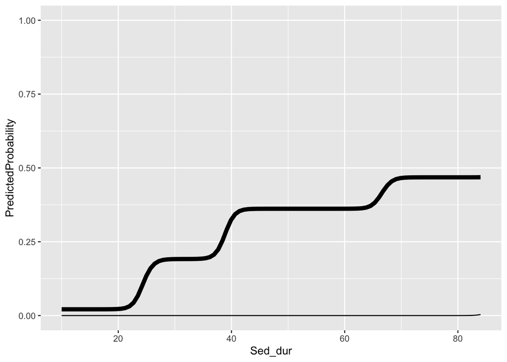

```r
#summary(growthSS2$Sed_exposure_days)
#   Min. 1st Qu.  Median    Mean 3rd Qu.    Max.
#   1.31   15.79   49.00   78.83  165.00  199.00

jvalues <- with(growthSS2, seq(from = min(Sed_exposure_days), to = max(Sed_exposure_days), length.out = 100))

# calculate predicted probabilities and store in a list
pp <- lapply(jvalues, function(j) {
    growthSS2$Sed_exposure_days <- j
    predict(modSS8, newdata = growthSS2, type = "response")
})

# average marginal predicted probability across a few different sediment levels
#sapply(pp[c(1, 20, 40, 60, 80, 100)], mean)
## [1] 0.1797186 0.1960244 0.2142042 0.2333993 0.2535694 0.2746604
# get the means with lower and upper quartiles
plotdat <- t(sapply(pp, function(x) {
    c(M = mean(x), med = median(x), quantile(x, c(0.25, 0.75)))
}))

# add in Sed_exposure_days values and convert to data frame
plotdat <- as.data.frame(cbind(plotdat, jvalues))

# better names and show the first few rows
colnames(plotdat) <- c("PredictedProbability", "MedianProbability",
                       "LowerQuantile", "UpperQuantile", "Sed_dur")
#head(plotdat)

# plot average marginal predicted probabilities
ggplot(plotdat, aes(x = Sed_dur)) +
  geom_line(aes(y = PredictedProbability), size = 2) +
  geom_line(aes(y = MedianProbability), size = 0.5) +
  ylim(c(0, 1))
```

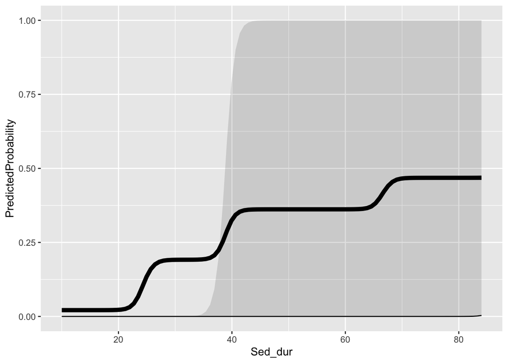

```r
ggplot(plotdat, aes(x = Sed_dur)) +
  geom_ribbon(aes(ymin = LowerQuantile, ymax = UpperQuantile), alpha = 0.15) +
  geom_line(aes(y = PredictedProbability), size = 2) +
  geom_line(aes(y = MedianProbability), size = 0.5) +
  ylim(c(0, 1))
```

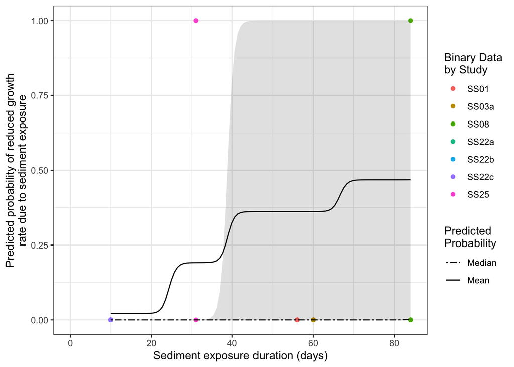

```r
#Overlaying average marginal predicted probabilities on figure
#by Ref
growthSS_plot3 <- ggplot() +
    geom_point(data = growthSS2, mapping = aes(
      x = Sed_exposure_days,
      y = Binary_reduced_growth,
      color = Ref)) +
    labs(x = "Sediment exposure duration (days)",
         y = "Predicted probability of reduced growth\nrate due to sediment exposure",
         color = "Binary Data\nby Study",
         linetype = "Predicted\nProbability") +
    scale_x_continuous(limits=c(0,max(growthSS2$Sed_exposure_days))) +
    geom_ribbon(data = plotdat, aes(x = Sed_dur, y = PredictedProbability,
                                    ymin = LowerQuantile, ymax = UpperQuantile),
                alpha = 0.15) +
    geom_line(data = plotdat, aes(x = Sed_dur, y = PredictedProbability,
                                  linetype = "twodash")) +
    geom_line(data = plotdat, aes(x = Sed_dur, y = MedianProbability,
                                  linetype = "solid")) +
    theme_bw() +
    scale_linetype_manual(values=c("twodash", "solid"), labels = c("Median","Mean"))

growthSS_plot3
```